# Notebook

### Web Information Retrieval and Data Mining - Assignment 3

```
Student: Siksma, Casper (0902066)
```

#### Answer 1.1, Baseline (4p)

- Dense network, at least 3 layers, shaped like a pyramid
  - Last layer: 10 nodes, sigmoid.
  - Loss: categorical cross-entropy. Metric: accuracy
- No preprocessing, regularization. Get at least 70% accuracy.
- Explain design decisions. Discuss performance.
  - Does it overfit (large/growing gap between loss and val_loss)?

[output not shown]

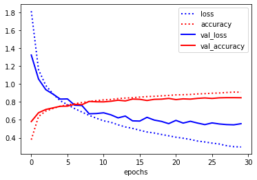

```
Model: "sequential"
_________________________________________________________________
Layer (type)                 Output Shape              Param #
=================================================================
reshape (Reshape)            (None, 3072)              0
_________________________________________________________________
dense (Dense)                (None, 3000)              9219000
_________________________________________________________________
dense_1 (Dense)              (None, 1500)              4501500
_________________________________________________________________
dense_2 (Dense)              (None, 500)               750500
_________________________________________________________________
dense_3 (Dense)              (None, 10)                5010
=================================================================
Total params: 14,476,010
Trainable params: 14,476,010
Non-trainable params: 0
_________________________________________________________________
None
def build_model_1_1():
    model = models.Sequential()
    model.add(layers.Reshape((3072,), input_shape=(32,32,3)))
    model.add(layers.Dense(3000, activation='relu'))
    model.add(layers.Dense(1500, activation='relu'))
    model.add(layers.Dense(500, activation='relu'))
    model.add(layers.Dense(10, activation='softmax'))
    model.compile(optimizer=tensorflow.keras.optimizers.Adam(lr=0.0001, amsgrad=True),
                  loss='categorical_crossentropy',
                  metrics=['accuracy'])
    return model
```

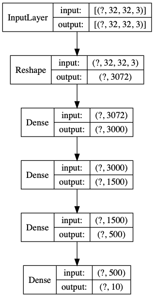

#### Answer 1.2, Preprocess (2p)

- Convert images to greyscale, other preprocessing optional.
  - Input shape should be (32,32,1)
- Explain design decisions. Is it better? Why (not)?
  - Color information is likely not so useful for classification. Greyscale makes the network smaller, less parameters to learn, less likely to overfit.

[output not shown]

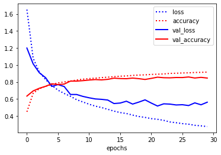

```
Model: "sequential_1"
_________________________________________________________________
Layer (type)                 Output Shape              Param #
=================================================================
reshape_1 (Reshape)          (None, 1024)              0
_________________________________________________________________
dense_4 (Dense)              (None, 3000)              3075000
_________________________________________________________________
dense_5 (Dense)              (None, 1500)              4501500
_________________________________________________________________
dense_6 (Dense)              (None, 500)               750500
_________________________________________________________________
dense_7 (Dense)              (None, 10)                5010
=================================================================
Total params: 8,332,010
Trainable params: 8,332,010
Non-trainable params: 0
_________________________________________________________________
None
def build_model_1_2():
    model = models.Sequential()
    model.add(layers.Reshape((1024,), input_shape=(32,32,1)))
    model.add(layers.Dense(3000, activation='relu'))
    model.add(layers.Dense(1500, activation='relu'))
    model.add(layers.Dense(500, activation='relu'))
    model.add(layers.Dense(10, activation='softmax'))
    model.compile(optimizer=tensorflow.keras.optimizers.Adam(lr=0.0001, amsgrad=True),
                  loss='categorical_crossentropy',
                  metrics=['accuracy'])
    return model
```

#### Answer 1.3, Tune (4p)

- Regularize the model. What works best?
  - Should consider batch normalization, dropout, l1/l2 regularization (or Nesterov)
- Tune other hyperparameters (e.g. learning rate, batch size,...) as you see fit.
  - At least consider tuning learning rate, ideally also momentum, decay, other optimizers
- Explain your findings and final design decisions. Discuss the results.
  - Should be better, at least it shouldn't overfit

[output not shown]

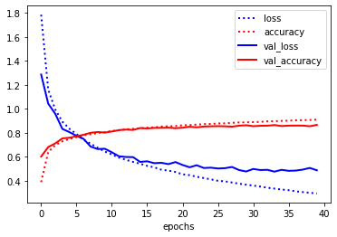

```
def build_model_1_3():
    model = models.Sequential()
    model.add(layers.Reshape((1024,), input_shape=(32,32,1)))
    model.add(layers.Dense(3000, activation='relu'))
    model.add(layers.Dropout(0.1))
    model.add(layers.Dense(1500, activation='relu'))
    model.add(layers.Dropout(0.1))
    model.add(layers.Dense(500, activation='relu'))
    model.add(layers.Dropout(0.2))
    model.add(layers.Dense(10, activation='softmax'))
    model.compile(optimizer=tensorflow.keras.optimizers.Adam(lr=0.0001, amsgrad=True),
                  loss='categorical_crossentropy',
                  metrics=['accuracy'])
    return model
```

#### Answer 2.1, ConvNet (7p)

- Build a sequential ConvNet, get at least 90% accuracy.
  - Conv2D layers, input shape (32,32,1)
  - Consider using blocks of Conv2D layers with maxpooling in between
  - Use zero-padding in Conv2D layers because the images are small
  - At least one dense hidden layer and dense output layer (sigmoid)
  - Consider adding batch normalization, dropout
  - Consider small dropout rates in beginning, larger dropout rates later in network
  - Consider other optimizers and tuning learning rate, momentum,...
- Explain what you did and why (800 chars). Is it working well?
  - Should be quite elaborate and sensible

[output not shown]

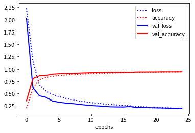

```
Model: "sequential_4"
_________________________________________________________________
Layer (type)                 Output Shape              Param #
=================================================================
reshape_4 (Reshape)          (None, 32, 32, 1)         0
_________________________________________________________________
conv2d_6 (Conv2D)            (None, 32, 32, 32)        320
_________________________________________________________________
batch_normalization_3 (Batch (None, 32, 32, 32)        128
_________________________________________________________________
conv2d_7 (Conv2D)            (None, 32, 32, 32)        9248
_________________________________________________________________
max_pooling2d_3 (MaxPooling2 (None, 16, 16, 32)        0
_________________________________________________________________
dropout_7 (Dropout)          (None, 16, 16, 32)        0
_________________________________________________________________
conv2d_8 (Conv2D)            (None, 16, 16, 64)        18496
_________________________________________________________________
batch_normalization_4 (Batch (None, 16, 16, 64)        256
_________________________________________________________________
conv2d_9 (Conv2D)            (None, 16, 16, 64)        36928
_________________________________________________________________
max_pooling2d_4 (MaxPooling2 (None, 8, 8, 64)          0
_________________________________________________________________
dropout_8 (Dropout)          (None, 8, 8, 64)          0
_________________________________________________________________
conv2d_10 (Conv2D)           (None, 8, 8, 128)         73856
_________________________________________________________________
batch_normalization_5 (Batch (None, 8, 8, 128)         512
_________________________________________________________________
conv2d_11 (Conv2D)           (None, 8, 8, 128)         147584
_________________________________________________________________
max_pooling2d_5 (MaxPooling2 (None, 4, 4, 128)         0
_________________________________________________________________
dropout_9 (Dropout)          (None, 4, 4, 128)         0
_________________________________________________________________
flatten_1 (Flatten)          (None, 2048)              0
_________________________________________________________________
dense_14 (Dense)             (None, 256)               524544
_________________________________________________________________
```

[output cut: 24 more lines]

```
    model.add(layers.BatchNormalization())
    model.add(layers.Conv2D(128, (3, 3), activation='relu',  padding='same'))
    model.add(layers.MaxPooling2D((2, 2)))
    model.add(layers.Dropout(0.2))

    model.add(layers.Flatten())

    model.add(layers.Dense(256, activation='relu'))
    model.add(layers.Dropout(0.3))

    model.add(layers.Dense(10, activation='softmax'))
    model.compile(optimizer=tensorflow.keras.optimizers.Adam(lr=0.0001, amsgrad=True),
                  loss='categorical_crossentropy',
                  metrics=['accuracy'])
    return model
```

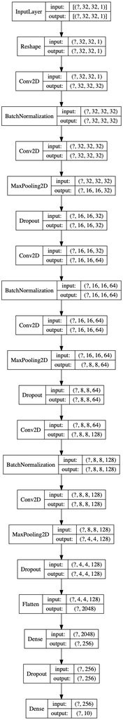

#### Answer 2.2, Data Augmentation (3p)

- Augment the preprocessed training data.
  - Use small variations (small shifts up-down, left-right) of flips becasue the images are small
  - Large shifts and rotations distort the image too much
- Explain what you did and why. Discuss the performance of the model.

[output not shown]

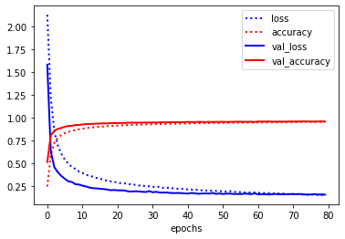

```
datagen = tensorflow.keras.preprocessing.image.ImageDataGenerator(rotation_range=10,
                             zoom_range=[0.85, 1.15],
                             height_shift_range=0.1,
                             shear_range=0.1)
```

#### Answer 3.1, Misclassifications (2p)

[output not shown]

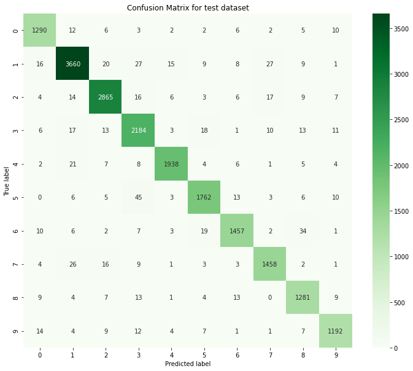

```
[8 2 1 ... 9 1 6]
[8 2 1 ... 9 1 6]
```

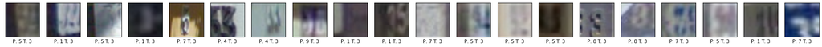

#### Answer 3.2, Activations (4p)

- Retrieve and visualize the activations for one example
- For every filter for different convolutional layers (at different depths in the network).
- Give an explanation. Is your model indeed learning something useful?
  - Should detect edges etc in first layers, higher-order object (e.g. interesting regions) in deeper layers.

[output not shown]

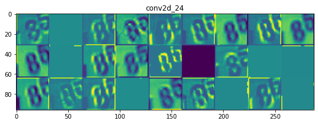

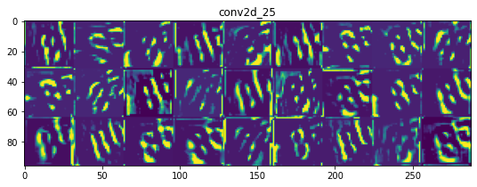

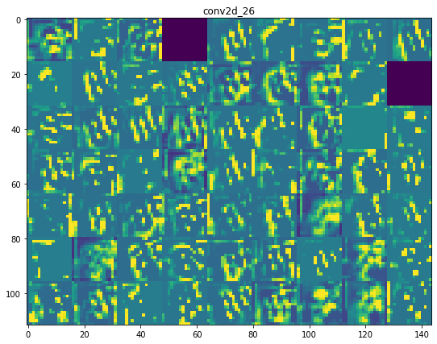

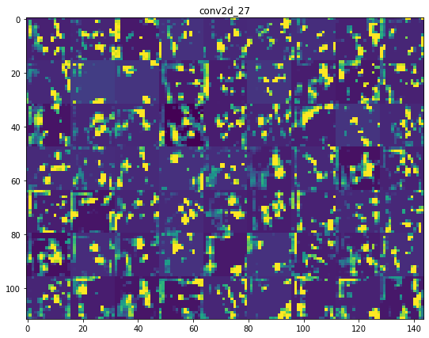

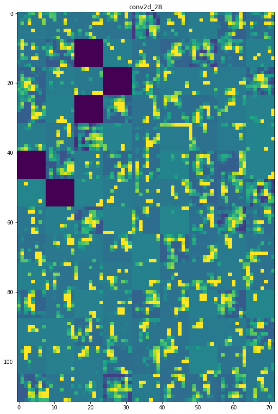

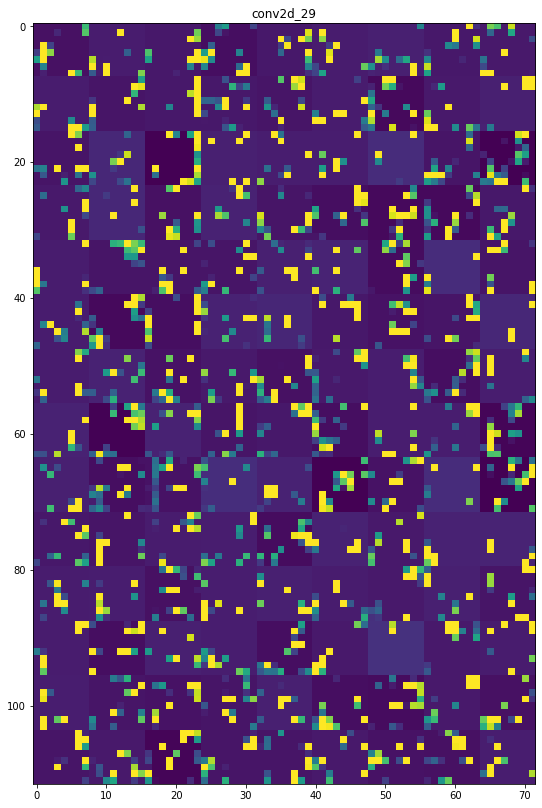

#### Answer 3.3, Class activation map (4p)

- Show a class activation map for your last convolutional layer
- Superimpose the activation map over the image, or plot side by side
  - Should make sense, detect interesting regions to classify the number

```
Model: "sequential_6"
_________________________________________________________________
Layer (type)                 Output Shape              Param #
=================================================================
reshape_6 (Reshape)          (None, 32, 32, 1)         0
_________________________________________________________________
conv2d_24 (Conv2D)           (None, 32, 32, 32)        320
_________________________________________________________________
batch_normalization_12 (Batc (None, 32, 32, 32)        128
_________________________________________________________________
conv2d_25 (Conv2D)           (None, 32, 32, 32)        9248
_________________________________________________________________
max_pooling2d_12 (MaxPooling (None, 16, 16, 32)        0
_________________________________________________________________
dropout_16 (Dropout)         (None, 16, 16, 32)        0
_________________________________________________________________
conv2d_26 (Conv2D)           (None, 16, 16, 64)        18496
_________________________________________________________________
batch_normalization_13 (Batc (None, 16, 16, 64)        256
_________________________________________________________________
conv2d_27 (Conv2D)           (None, 16, 16, 64)        36928
_________________________________________________________________
max_pooling2d_13 (MaxPooling (None, 8, 8, 64)          0
_________________________________________________________________
dropout_17 (Dropout)         (None, 8, 8, 64)          0
_________________________________________________________________
conv2d_28 (Conv2D)           (None, 8, 8, 128)         73856
_________________________________________________________________
batch_normalization_14 (Batc (None, 8, 8, 128)         512
_________________________________________________________________
conv2d_29 (Conv2D)           (None, 8, 8, 128)         147584
_________________________________________________________________
max_pooling2d_14 (MaxPooling (None, 4, 4, 128)         0
_________________________________________________________________
dropout_18 (Dropout)         (None, 4, 4, 128)         0
_________________________________________________________________
flatten_4 (Flatten)          (None, 2048)              0
_________________________________________________________________
dense_16 (Dense)             (None, 256)               524544
_________________________________________________________________
dropout_19 (Dropout)         (None, 256)               0
_________________________________________________________________
dense_17 (Dense)             (None, 10)                2570
=================================================================
Total params: 814,442
Trainable params: 813,994
Non-trainable params: 448
_________________________________________________________________
```

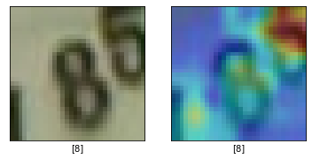

```
def plot_3_3():
  color_img = X_test[0]
  gray_img = rgb2gray([color_img])
  g = tensorflow.Graph()
  with g.as_default():
    model = load_model_from_file(base_dir, "model_2_2")

    model.summary()
    last_layer = model.get_layer('conv2d_29')
    y_test_pred = model.predict(gray_img)

    argmax = np.argmax(y_test_pred[0])
    output = model.output[:, argmax]

    # Disable eager execution
    tf.compat.v1.disable_eager_execution()
    grads = K.gradients(output, last_layer.output)[0]
    pooled_grads = K.mean(grads, axis=(0, 1, 2))
    iterate = K.function([model.input], [pooled_grads, last_layer.output[0]])
    pooled_grads_value, conv_layer_output_value = iterate([gray_img])

    for i in range(32):
      conv_layer_output_value[:, :, i] *= pooled_grads_value[i]

    heatmap = np.mean(conv_layer_output_value, axis=-1)
    heatmap = np.maximum(heatmap, 0)
    heatmap /= np.max(heatmap)


    heatmap = cv2.resize(heatmap, (32, 32))
    heatmap = np.uint8(255 * heatmap)
    heatmap = cv2.applyColorMap(heatmap, cv2.COLORMAP_JET)

    superimposed_img = cv2.addWeighted(np.uint8(255 * color_img), 0.6, heatmap, 0.4, 0)
    output = os.path.join(base_dir, 'superimposed.jpeg')
    cv2.imwrite(output, superimposed_img)

    img=mpimg.imread(output)

    plt.figure(figsize=(10, 15))

    f, axarr = plt.subplots(1, 2)
    axarr[0].imshow(color_img)
    axarr[0].set_xticks(()), axarr[0].set_yticks(())
    axarr[0].set_xlabel((np.argmax(y_test_pred, axis=1)+1)%10)
    axarr[1].imshow(img)
    axarr[1].set_xticks(()), axarr[1].set_yticks(())
    axarr[1].set_xlabel((np.argmax(y_test_pred, axis=1)+1)%10)

    plt.show()
```

#### Answer 4.1, Fast feature extraction (5p)

- Import the VGG16 model, pretrained on ImageNet
- Freeze convolutional base, adds a dense layer
- Consider unfreezing the last few convolutional layers and evaluate whether that works better
  - Check if they do. It is very likely to help.
- Discuss the observed performance
  - Should get around 80% accuracy

[output not shown]

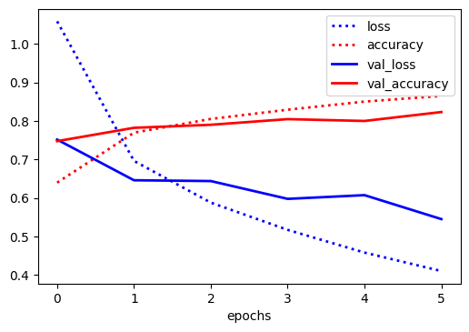

```
Model: "model"
_________________________________________________________________
Layer (type)                 Output Shape              Param #
=================================================================
input_1 (InputLayer)         [(None, 32, 32, 3)]       0
_________________________________________________________________
block1_conv1 (Conv2D)        (None, 32, 32, 64)        1792
_________________________________________________________________
block1_conv2 (Conv2D)        (None, 32, 32, 64)        36928
_________________________________________________________________
block1_pool (MaxPooling2D)   (None, 16, 16, 64)        0
_________________________________________________________________
block2_conv1 (Conv2D)        (None, 16, 16, 128)       73856
_________________________________________________________________
block2_conv2 (Conv2D)        (None, 16, 16, 128)       147584
_________________________________________________________________
block2_pool (MaxPooling2D)   (None, 8, 8, 128)         0
_________________________________________________________________
block3_conv1 (Conv2D)        (None, 8, 8, 256)         295168
_________________________________________________________________
block3_conv2 (Conv2D)        (None, 8, 8, 256)         590080
_________________________________________________________________
block3_conv3 (Conv2D)        (None, 8, 8, 256)         590080
_________________________________________________________________
block3_pool (MaxPooling2D)   (None, 4, 4, 256)         0
_________________________________________________________________
block4_conv1 (Conv2D)        (None, 4, 4, 512)         1180160
_________________________________________________________________
block4_conv2 (Conv2D)        (None, 4, 4, 512)         2359808
_________________________________________________________________
block4_conv3 (Conv2D)        (None, 4, 4, 512)         2359808
_________________________________________________________________
block4_pool (MaxPooling2D)   (None, 2, 2, 512)         0
_________________________________________________________________
block5_conv1 (Conv2D)        (None, 2, 2, 512)         2359808
_________________________________________________________________
block5_conv2 (Conv2D)        (None, 2, 2, 512)         2359808
_________________________________________________________________
block5_conv3 (Conv2D)        (None, 2, 2, 512)         2359808
_________________________________________________________________
```

[output cut: 16 more lines]

```
    top_model.add(layers.Dense(10, activation='softmax'))

    model = models.Model(inputs= base_model.input, outputs=top_model(base_model.output))

    for layer in model.layers[:-5]:
      layer.trainable = False

    print('Trainable layers:')
    for layer in model.layers:
        print(layer.name, layer.trainable)

    model.compile(optimizer=tensorflow.keras.optimizers.Adam(lr=0.0001, amsgrad=True),
                  loss='categorical_crossentropy',
                  metrics=['accuracy'])
    return model
```

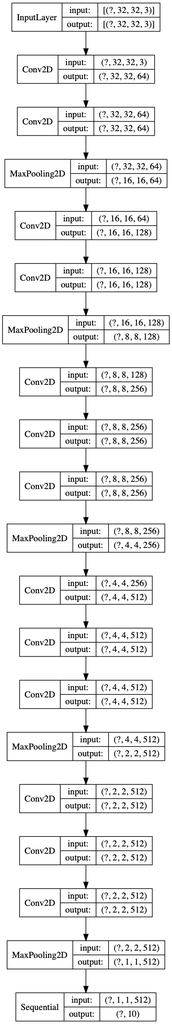

#### Answer 4.2, Embeddings (5p)

- Generate embeddings with the trained convolutional part of model_4_1 (without the dense layer)
- Embed the training and test data and store them to disk
- Build and evaluate a pipeline on the embedded data
  - Check if pipeline makes sense (e.g. use models that can handle many dimensions)
- Describe what you did and what you observed (max 800 chars).
  - Consider different models, preprocessing, tuning, etc.
  - Check performance (see original Submission.html) when in doubt. We did not run all the evaluations because it takes too long, and the output is ill-defined.

[output not shown]

```
Running time: 58.53 seconds
Last modified: May 26, 2020
scikit-learn version: 0.23.1
```